# AN INTRODUCTION TO DATABASE SYSTEMS

by Date C.

Examples are given in PosgreSQL.

# Vocabulary

| notion | description |
| --- | --- |
| **Concepts** |  |
| Closure | the relational property of having the output from any given relational operation to be another relation. |
| **Languages** |  |
| DDL | data definition language |
| DML | data manipulation language |
| DSL | data sub-language, the language users use on the external level |
| host language | the programming language of the DBMS |
| 4GL | Fourth generation languages (machine code, assembler, first high level languages, and 4GL) |
| **Architectures** |  |
| internal record | stored record |
| internal view | stored database |
| initernal schema | stored database definition |
| back-end | server |
| front-end | client |
| **Data Types** |  |
| ADT | abstract data types are types defined by ther user |
| observer or function | read-only operator |
| mutator | update operator |
| **Other** |  |
| DC manager | Data Communication manager |
| tools | vendor-provided, built-in applications |
| VLDB | Very Large DataBase |

# My API

```python
from postgres_connector import *

print("Your default database is \"%s\"." % MyQuery().dbname)
```

```
Your default database is "date_db".
```

## `explain analyze`

```python
test_one = MyQuery("SELECT * FROM resolution WHERE EXTRACT(YEAR FROM vote_date) = 1999;",
                   dbname="un_votes_mod")

test_one.explain(verbose=True)
```

```
EXPLAIN SELECT * FROM resolution WHERE EXTRACT(YEAR FROM vote_date) = 1999;
	 QUERY PLAN
--------------------------------------------------------------------------------
Bitmap Heap Scan on resolution  (cost=4.66..76.79 rows=49 width=30)
  Recheck Cond: (EXTRACT(year FROM vote_date) = '1999'::numeric)
  ->  Bitmap Index Scan on year_b  (cost=0.00..4.65 rows=49 width=0)
        Index Cond: (EXTRACT(year FROM vote_date) = '1999'::numeric)
```

```python
test_one.explain_analyze()
```

```
	 QUERY PLAN
--------------------------------------------------------------------------------
Bitmap Heap Scan on resolution  (cost=4.66..76.79 rows=49 width=30) (actual time=0.028..0.046 rows=135 loops=1)
  Recheck Cond: (EXTRACT(year FROM vote_date) = '1999'::numeric)
  Heap Blocks: exact=2
  ->  Bitmap Index Scan on year_b  (cost=0.00..4.65 rows=49 width=0) (actual time=0.022..0.023 rows=135 loops=1)
        Index Cond: (EXTRACT(year FROM vote_date) = '1999'::numeric)
Planning Time: 0.524 ms
Execution Time: 0.118 ms
```

## `psql` commands

You can pass any psql commands using `psql` method:

```python
MyQuery().psql('\dt')
```

```
            List of relations
 Schema |      Name      | Type  | Owner
--------+----------------+-------+-------
 public | j              | table | user1
 public | p              | table | user1
 public | part_structure | table | user1
 public | s              | table | user1
 public | sp             | table | user1
 public | spj            | table | user1
(6 rows)
```

Pass your query into `psql` method. The query will be executed well even if you pass it straight to the `__init__` method (the query will be passed to the `psql` method as an instance atttribute), but in this case you will see the error of the incorrect SQL query, since psql commands are unique to PostgreSQL. No query in initialization step will not call the execution of the query as an SQL command and, thus, no error will be produced.

```python
MyQuery('\dt').psql()
```

```
ERROR in self.__init__: syntax error at or near "\"
LINE 1: \dt
        ^

            List of relations
 Schema |      Name      | Type  | Owner
--------+----------------+-------+-------
 public | j              | table | user1
 public | p              | table | user1
 public | part_structure | table | user1
 public | s              | table | user1
 public | sp             | table | user1
 public | spj            | table | user1
(6 rows)
```

```python
MyQuery(dbname="un_votes_mod").psql(
    """
    SELECT * FROM resolution WHERE EXTRACT(YEAR FROM vote_date) = 1999 LIMIT 10;
    """
)
```

```
   id   | title_id |    symbol    | meeting_record_id | vote_date
--------+----------+--------------+-------------------+------------
 404946 |     3725 | A/RES/54/197 |              2227 | 1999-12-22
 404978 |     3568 | A/RES/54/200 |              2227 | 1999-12-22
 404979 |     3569 | A/RES/54/230 |              2227 | 1999-12-22
 404565 |     3726 | A/RES/54/151 |              2228 | 1999-12-17
 404566 |     3352 | A/RES/54/152 |              2228 | 1999-12-17
 404567 |     3574 | A/RES/54/164 |              2228 | 1999-12-17
 404568 |     3727 | A/RES/54/165 |              2228 | 1999-12-17
 404569 |     2928 | A/RES/54/168 |              2228 | 1999-12-17
 404570 |     3353 | A/RES/54/169 |              2228 | 1999-12-17
 404571 |     3572 | A/RES/54/172 |              2228 | 1999-12-17
(10 rows)
```

## get pandas dataframe

```python
MyQuery(
    """
    SELECT * FROM resolution WHERE EXTRACT(YEAR FROM vote_date) = 1999 LIMIT 10;
    """,
    dbname="un_votes_mod"
).get_df()
```

|  | id | title_id | symbol | meeting_record_id | vote_date |
| --- | --- | --- | --- | --- | --- |
| 0 | 404946 | 3725 | A/RES/54/197 | 2227 | 1999-12-22 |
| 1 | 404978 | 3568 | A/RES/54/200 | 2227 | 1999-12-22 |
| 2 | 404979 | 3569 | A/RES/54/230 | 2227 | 1999-12-22 |
| 3 | 404565 | 3726 | A/RES/54/151 | 2228 | 1999-12-17 |
| 4 | 404566 | 3352 | A/RES/54/152 | 2228 | 1999-12-17 |
| 5 | 404567 | 3574 | A/RES/54/164 | 2228 | 1999-12-17 |
| 6 | 404568 | 3727 | A/RES/54/165 | 2228 | 1999-12-17 |
| 7 | 404569 | 2928 | A/RES/54/168 | 2228 | 1999-12-17 |
| 8 | 404570 | 3353 | A/RES/54/169 | 2228 | 1999-12-17 |
| 9 | 404571 | 3572 | A/RES/54/172 | 2228 | 1999-12-17 |

## get list of items

```python
MyQuery(
    """
    SELECT * FROM resolution WHERE EXTRACT(YEAR FROM vote_date) = 1999 LIMIT 10;
    """,
    dbname="un_votes_mod"
).get_list("symbol")
```

```
['A/RES/54/197',
 'A/RES/54/200',
 'A/RES/54/230',
 'A/RES/54/151',
 'A/RES/54/152',
 'A/RES/54/164',
 'A/RES/54/165',
 'A/RES/54/168',
 'A/RES/54/169',
 'A/RES/54/172']
```

and many other useful commands.

# 2. Database System Architecture

## 2.8 The database management system

Overall purpose of the DBMS is to provide the user interface to the database system, i.e.to support the creation and execution of applications. That is, this is the external level.

### Functions of the DBMS

- **Data definition**
  - DDL processor/compiler for of the various DDLs to be able to accept data definitions (external schemas, the conceptual schema, the internal schema, and all associated mappings);
- **Data manipulation**
  - DML proceccor/compiler to handle requests to retrieve, update, or delete existing data in the db or add new data to the db
  - DML requests can be **plannded** (operational or production applications) or **unplanned** (decision support applications);
- **Optimization and execution** (see chapter 18 for details)
  - optimizer component implements the optimized DML request, and the run-time manager executes it;
- **Data security and integrity**
  - can be carried at compile time or run time, or some mixture of two;
- **Data recovery and concurency** (see Part IV)
  - transaction manager (is not usually the part of the DBMS per se) or TP monitor
- **Catalog** (also: data dictionary, data repository, data encyclopedia)
  - metadata or descriptors - definitions of other objects in the system, instead of just "raw data" (all the various schemas and mappings are kept in the data dictionary)
  - it is possible to query this database
- **Performance**.

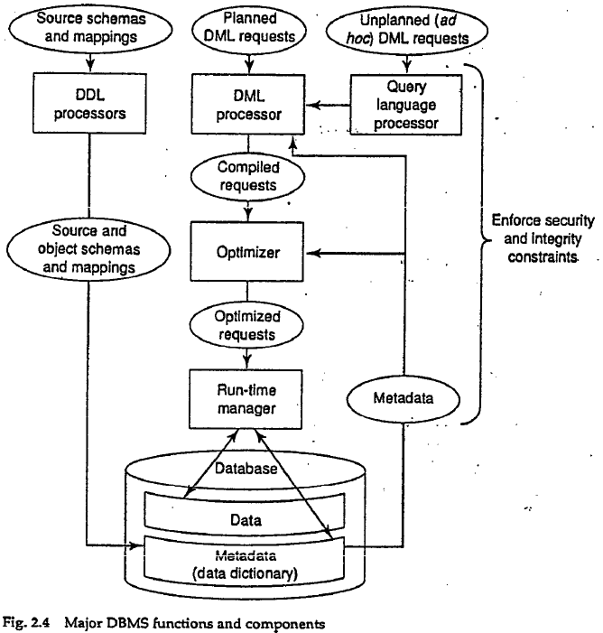

*Major DBMS functions and components*

### File manager (File server)

File management system is the component of the underlying operating system that manages stored files, i.e. the DBMS is built on top of file manager. Thus, the user can of a file management system is able to create and destroy stored files and perform simple retrieval and upate operations on stored records in such files.

File managers lack all the benefits of the databases, like data integrity and security, data recovery and concurrncy, and so on.

## 2.9 Data communications

Data communications (DC) manager is not part of the DBMS but it is an autonomous system in its own right.

The DBMS looks after the database and the DC manager handles all the messages to and from applications that use the DBMS.

## 2.10 Client/Server Architecture

The basis for distributed processing - the distinct machines can be connected into some kind of communications network in such a way that a single data processing task can be spread across several machines in the network.

- Server
  - is just the DBMS itself
- Client
  - are various applications that run on top of the DBMS - both user written applications and built-in (vendor-provided) applications (so called tools).

Tools are designed to assist in the creation and execution of other applications. They can be divided into several more or less distinct classes:

- query language processors
- report writers
- business graphics subsystems
- spreadshits
- natural language processors
- statistical packages
- copy management or "data extract" tools
- application generators (including 4GL)
- other application development tools, including computer-aided software engineering (CASE) products
- data mining and vusualization tools  
  and many others.

These tools are the major factor in "the database decision" (i.e. choosing the right database product).

## 2.11 Utilities

Some utilities can be provided by the vendor and some by the third party.

Examples of typically needed utilities:

- Load routines
- Unload/reload and dump/restore routines
- Reorganization routines
- Statistical routines
- Analysis routines  
  etc.

# 3. An Introduction to Relational Databases

## 3.2 An Informal Look at the Relational Model

Three main aspects:

- **Structural aspect**: The data in the database is perceived by the user as tables, and nothing but tables.
- **Integrity aspect**: Those tables satisfy certain integrity constraints, to be discussed toward the end of this section.
- **Manipulative aspect**: three most important are
  - restrict - extracts specified rows from a table,
  - project - extract specified colums from a table,
  - join - combines two tables into one on the basis of common values in a common column.

The result of each of the three operations (restrict, project, join) is another table, and thus the output from one operation can become input to another, i.e.

> it is possible to write **nested relational expressions**.

The system tries very hard not to materialize intermediate results in their entirety:

- **materialized evaluation** - intermediate results are fully materialized,
- **pipelined evaluation** - intermediate results are passed piecemeal to subsequent operations.

The operations are all **set-at-a-time**, not row-at-a-time, i.e. the operands and results are whole tables, not just single rows, and tables contain **sets** of rows. By contrast, the operations in non-relational systems are typically at the row- or record-at-a-time level; thus, this **set processing capability** is a major distinguishing characteristis of relational systems.

The conceptual and external levels (*logical structure*) in a relational system will both be relational, but the internal level will not be.

**The information principle**:

- the entire information content of the database is represented in one and only one way - as explicit values in column positions in rows and tables.

There are no *pointers* connecting one table to another at the conceptual and external levels (i.e. seen by the user), as in non-relational database systems.

### A more formal definition

Five components of the relational model:

1. An open-ended collection of **scalar types** (including the particular the type of boolean).
2. A **relation type generator** and an intended interpretation for relations of types generated thereby.
3. Facilities for defining **relation variables** of such generated relation types.
4. A **relation assignment** operation for assigning relation values to such relation variables.
5. An open-ended collection of generic **relational operators** ("the relational algebra") for deriving relation values from other relation values.

## 3.3 Relations and relvars

**Relation** is a mathematical term for the table of a special kind (see Ch. 6 for details):

- the relational model is mainly based on set theory and predicate logic,
- Codd E.F "A Relational Model of Data for Large Shared Data Banks"

Now, suppose we implement `DELETE` operation in SQL - we're deleting `row` number 3 in the given table `table_1`.

```
DELETE table_1 WHERE row = row (3);
```

In this case the old **relation value** of `table_1` is replaced en bloc by an entirely new relation value which looks very similar (they differ with one row only), but conceptually they are different values (see Ch. 6). We have an assignment operation:

```
table_1 := table_1 WHERE NOT (row = row (3) );
```

- the expression on the right side is evaluated,
- the result of that evaluation is assigned to the *variable* on the left side.

There must be the distinction between *relation values* and *relation variables*.

> Note: update operations and integrity constraints (see Ch. 6 and 9 respectively) both apply specifically to relvars, not relations.

## 3.4 What Relations Mean

A very important way of thinking about relations:

1. Given a relation `r`, the heading of `r` denotes a certain **predicate** (where a predicate is just a *truth-valued function* that takes a set of *paremeters*).
2. Each row in the body of `r` denotes a certain true proposition, obtained from the predicate by substituting certain *argument* values of the appropriate type for the parameters of the predicate ("instantiating the predicate").

These headings are **types** (domains). Types are to relations as nouns are to sentences.

1. Types and relations (relation value) are both necessary (without types we have nothing to talk about, and without relations we cannot say anything).
2. Types and relations are sufficient, as well as necessary - that is, we do need anything else, logically speaking.
3. Types and relations are not the same thing.

Every relation has an associated predicate, including relations that are derived from others by means of operations such as join.

Relvars have predicates too: the predicate that is common to all of the relations that are possible values of the relvar in question.

## 3.5 Optimization

Relational systems perform **automatic navigation**, i.e. relational languages are nonprocedural - users specify *what*, not *how*.

**Optimizer** decides how to perform the automatic navigation.

Let's consider this query:

```python
query = "SELECT * FROM resolution WHERE EXTRACT(YEAR FROM vote_date) = 1999;"
```

There are at least two ways of performing the necessary data access:

- By doing a physical sequential scan of (the stored version of) relvar `resolution` until the required data is found:

```python
MyQuery(dbname="un_votes_mod").psql("DROP INDEX IF EXISTS year_b;")
```

```
DROP INDEX
```

```python
MyQuery(query=query, dbname="un_votes_mod").explain_analyze()
```

```
	 QUERY PLAN
--------------------------------------------------------------------------------
Seq Scan on resolution  (cost=0.00..222.98 rows=49 width=30) (actual time=3.035..4.187 rows=135 loops=1)
  Filter: (EXTRACT(year FROM vote_date) = '1999'::numeric)
  Rows Removed by Filter: 9664
Planning Time: 1.304 ms
Execution Time: 4.288 ms
```

- If there is an index on (the stored version of) the `vote_date` column, then by using this index to go directly to the required data

B-Tree index on `resolution (EXTRACT (YEAR FROM vote_date))`

```python
MyQuery(dbname="un_votes_mod").psql("CREATE INDEX IF NOT EXISTS year_b ON resolution(EXTRACT (YEAR FROM vote_date));")
```

```
CREATE INDEX
```

```python
MyQuery(query=query, dbname="un_votes_mod").explain_analyze()
```

```
	 QUERY PLAN
--------------------------------------------------------------------------------
Bitmap Heap Scan on resolution  (cost=4.66..76.79 rows=49 width=30) (actual time=0.054..0.081 rows=135 loops=1)
  Recheck Cond: (EXTRACT(year FROM vote_date) = '1999'::numeric)
  Heap Blocks: exact=2
  ->  Bitmap Index Scan on year_b  (cost=0.00..4.65 rows=49 width=0) (actual time=0.039..0.039 rows=135 loops=1)
        Index Cond: (EXTRACT(year FROM vote_date) = '1999'::numeric)
Planning Time: 0.793 ms
Execution Time: 0.205 ms
```

Users and user programs are thus independent of such access strategies, which is of course essential if data independence is to be achieved.

Also see: subqueries vs joins (subqueries do not allow the DBMS to optimize the query).

## 3.6 Catalog

The same as **dictionary**.

It contains:

- metadata, or descriptor information
- used by
  - optimizer for queries implementation decisions
  - authorization subsystem

It is contained with:

- system relvars

```python
MyQuery("\dt").psql()
```

```
                  List of relations
 Schema |            Name             | Type  | Owner
--------+-----------------------------+-------+-------
 public | agenda                      | table | user1
 public | committee_report            | table | user1
 public | country                     | table | user1
 public | meeting_record              | table | user1
 public | readme_en                   | table | user1
 public | readme_ru                   | table | user1
 public | resolution                  | table | user1
 public | resolution_agenda           | table | user1
 public | resolution_committee_report | table | user1
 public | subject                     | table | user1
 public | title                       | table | user1
 public | vote                        | table | user1
 public | vote_choice                 | table | user1
(13 rows)
```

Schema of the `resolution` table:

```python
MyQuery("\d resolution").psql()
```

```
                         Table "public.resolution"
      Column       |         Type          | Collation | Nullable | Default
-------------------+-----------------------+-----------+----------+---------
 id                | integer               |           | not null |
 title_id          | integer               |           |          |
 symbol            | character varying(64) |           |          |
 meeting_record_id | integer               |           |          |
 vote_date         | date                  |           |          |
Indexes:
    "resolution_pkey" PRIMARY KEY, btree (id)
    "month_b" btree (EXTRACT(month FROM vote_date))
    "resolution_symbol_key" UNIQUE CONSTRAINT, btree (symbol)
    "year_b" btree (EXTRACT(year FROM vote_date))
Foreign-key constraints:
    "resolution_meeting_record_id_fkey" FOREIGN KEY (meeting_record_id) REFERENCES meeting_record(id) ON DELETE CASCADE
    "resolution_title_id_fkey" FOREIGN KEY (title_id) REFERENCES title(id) ON DELETE CASCADE
Referenced by:
    TABLE "resolution_agenda" CONSTRAINT "resolution_agenda_resolution_id_fkey" FOREIGN KEY (resolution_id) REFERENCES resolution(id) ON DELETE CASCADE
    TABLE "resolution_committee_report" CONSTRAINT "resolution_committee_report_resolution_id_fkey" FOREIGN KEY (resolution_id) REFERENCES resolution(id) ON DELETE CASCADE
    TABLE "vote" CONSTRAINT "vote_resolution_id_fkey" FOREIGN KEY (resolution_id) REFERENCES resolution(id) ON DELETE CASCADE
```

And now let's find out what relvars contain `name` column:

```python
MyQuery("""
        SELECT column_name, table_name
            FROM information_schema.columns
            WHERE table_schema = 'public' AND column_name = 'name';
        """).get_df()
```

|  | column_name | table_name |
| --- | --- | --- |
| 0 | name | title |
| 1 | name | subject |
| 2 | name | agenda |
| 3 | name | country |

```python
MyQuery("""
        SELECT * FROM information_schema.columns;
        """).get_df()
```

|  | table_catalog | table_schema | table_name | column_name | ordinal_position | column_default | is_nullable | data_type | character_maximum_length | character_octet_length | ... | is_identity | identity_generation | identity_start | identity_increment | identity_maximum | identity_minimum | identity_cycle | is_generated | generation_expression | is_updatable |
| --- | --- | --- | --- | --- | --- | --- | --- | --- | --- | --- | --- | --- | --- | --- | --- | --- | --- | --- | --- | --- | --- |
| 0 | un_votes | pg_catalog | pg_type | typsubscript | 13 | None | NO | regproc | NaN | NaN | ... | NO | None | None | None | None | None | NO | NEVER | None | YES |
| 1 | un_votes | pg_catalog | pg_language | lanpltrusted | 5 | None | NO | boolean | NaN | NaN | ... | NO | None | None | None | None | None | NO | NEVER | None | YES |
| 2 | un_votes | pg_catalog | pg_class | relpersistence | 16 | None | NO | "char" | NaN | NaN | ... | NO | None | None | None | None | None | NO | NEVER | None | YES |
| 3 | un_votes | pg_catalog | pg_stat_sys_indexes | relname | 4 | None | YES | name | NaN | NaN | ... | NO | None | None | None | None | None | NO | NEVER | None | NO |
| 4 | un_votes | pg_catalog | pg_stat_ssl | client_dn | 6 | None | YES | text | NaN | 1.073742e+09 | ... | NO | None | None | None | None | None | NO | NEVER | None | NO |
| ... | ... | ... | ... | ... | ... | ... | ... | ... | ... | ... | ... | ... | ... | ... | ... | ... | ... | ... | ... | ... | ... |
| 1883 | un_votes | public | resolution | vote_date | 5 | None | YES | date | NaN | NaN | ... | NO | None | None | None | None | None | NO | NEVER | None | YES |
| 1884 | un_votes | pg_catalog | pg_subscription | subskiplsn | 3 | None | NO | pg_lsn | NaN | NaN | ... | NO | None | None | None | None | None | NO | NEVER | None | YES |
| 1885 | un_votes | pg_catalog | pg_statistic_ext | stxnamespace | 4 | None | NO | oid | NaN | NaN | ... | NO | None | None | None | None | None | NO | NEVER | None | YES |
| 1886 | un_votes | information_schema | tables | reference_generation | 6 | None | YES | character varying | NaN | 1.073742e+09 | ... | NO | None | None | None | None | None | NO | NEVER | None | NO |
| 1887 | un_votes | pg_catalog | pg_constraint | conpfeqop | 21 | None | YES | ARRAY | NaN | NaN | ... | NO | None | None | None | None | None | NO | NEVER | None | YES |

1888 rows × 44 columns

```python
MyQuery("""
        SELECT DISTINCT ON (table_name, table_schema)
            table_schema, table_name AS relation
            FROM information_schema.columns
            WHERE table_schema = 'public'
            ORDER BY relation;
        """).get_df()
```

|  | table_schema | relation |
| --- | --- | --- |
| 0 | public | agenda |
| 1 | public | committee_report |
| 2 | public | country |
| 3 | public | meeting_record |
| 4 | public | readme_en |
| 5 | public | readme_ru |
| 6 | public | resolution |
| 7 | public | resolution_agenda |
| 8 | public | resolution_committee_report |
| 9 | public | subject |
| 10 | public | title |
| 11 | public | vote |
| 12 | public | vote_choice |

Schema of `information_schema.columns`:

```python
MyQuery("\d information_schema.columns").psql()
```

```
                               View "information_schema.columns"
          Column          |                Type                | Collation | Nullable | Default
--------------------------+------------------------------------+-----------+----------+---------
 table_catalog            | information_schema.sql_identifier  |           |          |
 table_schema             | information_schema.sql_identifier  |           |          |
 table_name               | information_schema.sql_identifier  |           |          |
 column_name              | information_schema.sql_identifier  |           |          |
 ordinal_position         | information_schema.cardinal_number |           |          |
 column_default           | information_schema.character_data  |           |          |
 is_nullable              | information_schema.yes_or_no       |           |          |
 data_type                | information_schema.character_data  |           |          |
 character_maximum_length | information_schema.cardinal_number |           |          |
 character_octet_length   | information_schema.cardinal_number |           |          |
 numeric_precision        | information_schema.cardinal_number |           |          |
 numeric_precision_radix  | information_schema.cardinal_number |           |          |
 numeric_scale            | information_schema.cardinal_number |           |          |
 datetime_precision       | information_schema.cardinal_number |           |          |
 interval_type            | information_schema.character_data  |           |          |
 interval_precision       | information_schema.cardinal_number |           |          |
 character_set_catalog    | information_schema.sql_identifier  |           |          |
 character_set_schema     | information_schema.sql_identifier  |           |          |
 character_set_name       | information_schema.sql_identifier  |           |          |
 collation_catalog        | information_schema.sql_identifier  |           |          |
 collation_schema         | information_schema.sql_identifier  |           |          |
 collation_name           | information_schema.sql_identifier  |           |          |
 domain_catalog           | information_schema.sql_identifier  |           |          |
 domain_schema            | information_schema.sql_identifier  |           |          |
 domain_name              | information_schema.sql_identifier  |           |          |
 udt_catalog              | information_schema.sql_identifier  |           |          |
 udt_schema               | information_schema.sql_identifier  |           |          |
 udt_name                 | information_schema.sql_identifier  |           |          |
 scope_catalog            | information_schema.sql_identifier  |           |          |
 scope_schema             | information_schema.sql_identifier  |           |          |
 scope_name               | information_schema.sql_identifier  |           |          |
 maximum_cardinality      | information_schema.cardinal_number |           |          |
 dtd_identifier           | information_schema.sql_identifier  |           |          |
 is_self_referencing      | information_schema.yes_or_no       |           |          |
 is_identity              | information_schema.yes_or_no       |           |          |
 identity_generation      | information_schema.character_data  |           |          |
 identity_start           | information_schema.character_data  |           |          |
 identity_increment       | information_schema.character_data  |           |          |
 identity_maximum         | information_schema.character_data  |           |          |
 identity_minimum         | information_schema.character_data  |           |          |
 identity_cycle           | information_schema.yes_or_no       |           |          |
 is_generated             | information_schema.character_data  |           |          |
 generation_expression    | information_schema.character_data  |           |          |
 is_updatable             | information_schema.yes_or_no       |           |          |
```

## 3.7 Base relvars and views

**Base relvars** - original relvars, and **base relations** are their values:

- `CREATE TABLE relname`, where `TABLE` is the the base relvar with the name `relname`.

A relation that can be obtained from the base relations is called **derived**, or **derivable**, relation, and the relvar is called **view**, or **virtual relvars**:

- `CREATE VIEW viewname AS ...`, where
  - `VIEW` is view,
  - `...` is **view-defining expression** which is not evaluated but remembered by the system in the catalog, but the user can call it as a regular relvar in the database with the name `viewname`.

**Expressible relations** are collectively base and derived relations.

View is not the copy of the data, it is just another view of base relations, so any changes to views will be applied to the base relations. When you query the view, the query is optimized and executed on the base relvars, so for the human the view is just like a shortcut (kind of function?).

A view definition can be of arbitrary complexity (it can even refer to other views).

The fact that the view is a relvar is precisely one of the strengths of relational systems (like subset is also a set, in mathematics). Thus, **tables** are base relvars *and* views.

And one should never forget that the internal, conceptual, and external views of ANSI/SPARK are just an abstraction on the physically stored data, and the base relvars should not be considered as "real" data representation.

## 3.8 Transactions

```
BEGIN TRANSACTION ;  /* move $$$ from account A to account B */
UPDATE account A ;                           /* withdrawal */
UPDATE account B ;                           /* deposit */
IF everything worked fine
    THEN COMMIT ;                            /* normal end */
    ELSE ROLLBACK ;                          /* abnormal end */
END IF ;
```

For more details, see Ch. 15 and 16.

# 4. An Introduction to SQL

Brad Kelechava [The SQL Standard – ISO/IEC 9075:2023 (ANSI X3.135)](https://blog.ansi.org/sql-standard-iso-iec-9075-2023-ansi-x3-135/)

## 4.2 Overview

### Data definition operations

- [`CREATE TYPE`](https://www.postgresql.org/docs/current/sql-createtype.html)
- [`CREATE TABLE`](https://www.postgresql.org/docs/current/sql-createtable.html)

### Data manipulation operations

These are all *set-level* operations:

- [`SELECT`](https://www.postgresql.org/docs/16/sql-select.html)
  - `SELECT * FROM tablename;` is equal to `TABLE tablename;`
- [`INSERT`](https://www.postgresql.org/docs/16/sql-insert.html)
- [`DELETE`](https://www.postgresql.org/docs/16/sql-delete.html)
- [`UPDATE`](https://www.postgresql.org/docs/16/sql-update.html)

```python
MyQuery('TABLE resolution LIMIT 5;').get_df()
```

|  | id | title_id | symbol | meeting_record_id | vote_date |
| --- | --- | --- | --- | --- | --- |
| 0 | 280467 | 1 | S/RES/15(1946) | 1 | 1946-12-19 |
| 1 | 280489 | 2 | S/RES/37(1947) | 2 | 1947-12-09 |
| 2 | 671195 | 3 | A/RES/181(II)[A] | 3 | 1947-11-29 |
| 3 | 671185 | 4 | A/RES/117(II) | 4 | 1947-11-21 |
| 4 | 671187 | 5 | A/RES/174(II) | 4 | 1947-11-21 |

```python
MyQuery('SELECT * FROM resolution LIMIT 5;').get_df()
```

|  | id | title_id | symbol | meeting_record_id | vote_date |
| --- | --- | --- | --- | --- | --- |
| 0 | 280467 | 1 | S/RES/15(1946) | 1 | 1946-12-19 |
| 1 | 280489 | 2 | S/RES/37(1947) | 2 | 1947-12-09 |
| 2 | 671195 | 3 | A/RES/181(II)[A] | 3 | 1947-11-29 |
| 3 | 671185 | 4 | A/RES/117(II) | 4 | 1947-11-21 |
| 4 | 671187 | 5 | A/RES/174(II) | 4 | 1947-11-21 |

## 4.3 Catalog - Information Schema

- SQL catalog consists of the descriptors for an individual database (there is no "database" term in SQL standard),
- SQL schema consists of the descriptors for that portion of that database that belongs to some individual user.

Each catalog is required to include exactly one schema called `INFORMATION_SCHEMA`, and from the user's perspective this schema performs the normal catalog function:

- information schema is defined to contain a set of views of a hypothetical "Definition Schema", but not constrained to be exactly "Definition Schema"
- each database has its own information schema, there is no one common information schema.

```python
MyQuery("SELECT * FROM information_schema.tables LIMIT 5;").get_df().columns
```

```
Index(['table_catalog', 'table_schema', 'table_name', 'table_type',
       'self_referencing_column_name', 'reference_generation',
       'user_defined_type_catalog', 'user_defined_type_schema',
       'user_defined_type_name', 'is_insertable_into', 'is_typed',
       'commit_action'],
      dtype='object')
```

```python
MyQuery("""
    SELECT table_name
        FROM information_schema.tables
        WHERE table_schema = 'information_schema' AND table_type = 'VIEW';
        """
).get_df()
```

|  | table_name |
| --- | --- |
| 0 | role_column_grants |
| 1 | information_schema_catalog_name |
| 2 | column_domain_usage |
| 3 | applicable_roles |
| 4 | administrable_role_authorizations |
| 5 | domain_constraints |
| 6 | attributes |
| 7 | column_privileges |
| 8 | character_sets |
| 9 | check_constraint_routine_usage |
| 10 | check_constraints |
| 11 | column_udt_usage |
| 12 | collations |
| 13 | collation_character_set_applicability |
| 14 | key_column_usage |
| 15 | column_column_usage |
| 16 | columns |
| 17 | domain_udt_usage |
| 18 | constraint_column_usage |
| 19 | constraint_table_usage |
| 20 | domains |
| 21 | referential_constraints |
| 22 | enabled_roles |
| 23 | parameters |
| 24 | routine_column_usage |
| 25 | routine_privileges |
| 26 | role_routine_grants |
| 27 | routine_routine_usage |
| 28 | table_privileges |
| 29 | routine_sequence_usage |
| 30 | routine_table_usage |
| 31 | udt_privileges |
| 32 | routines |
| 33 | role_table_grants |
| 34 | schemata |
| 35 | sequences |
| 36 | tables |
| 37 | table_constraints |
| 38 | view_routine_usage |
| 39 | role_udt_grants |
| 40 | triggered_update_columns |
| 41 | triggers |
| 42 | user_defined_types |
| 43 | usage_privileges |
| 44 | role_usage_grants |
| 45 | view_column_usage |
| 46 | view_table_usage |
| 47 | views |
| 48 | data_type_privileges |
| 49 | element_types |
| 50 | column_options |
| 51 | foreign_data_wrapper_options |
| 52 | foreign_data_wrappers |
| 53 | foreign_server_options |
| 54 | foreign_servers |
| 55 | foreign_table_options |
| 56 | foreign_tables |
| 57 | user_mapping_options |
| 58 | user_mappings |

## 4.4 Views

### Create view

```python
MyQuery("""
    CREATE VIEW egypt
        AS SELECT resolution.symbol as symbol, title.name as title,
                    vote_choice.choice, resolution.vote_date as date
            FROM RESOLUTION
            JOIN vote ON resolution.id = vote.resolution_id
            JOIN title ON resolution.title_id = title.id
            JOIN country ON vote.country_id = country.id
            JOIN vote_choice ON vote_choice.id = vote.vote_choice_id
            WHERE country.name ~* 'egypt'
            ORDER BY EXTRACT(YEAR FROM resolution.vote_date) DESC;
    """)
```

```
<helpers.MyQuery at 0x7f66fdc13e90>
```

```python
MyQuery("\d").psql()
```

```
                    List of relations
 Schema |            Name             |   Type   | Owner
--------+-----------------------------+----------+-------
 public | agenda                      | table    | user1
 public | agenda_id_seq               | sequence | user1
 public | committee_report            | table    | user1
 public | committee_report_id_seq     | sequence | user1
 public | country                     | table    | user1
 public | country_id_seq              | sequence | user1
 public | egypt                       | view     | user1
 public | meeting_record              | table    | user1
 public | meeting_record_id_seq       | sequence | user1
 public | readme_en                   | table    | user1
 public | readme_en_id_seq            | sequence | user1
 public | readme_ru                   | table    | user1
 public | readme_ru_id_seq            | sequence | user1
 public | resolution                  | table    | user1
 public | resolution_agenda           | table    | user1
 public | resolution_committee_report | table    | user1
 public | subject                     | table    | user1
 public | subject_id_seq              | sequence | user1
 public | title                       | table    | user1
 public | title_id_seq                | sequence | user1
 public | vote                        | table    | user1
 public | vote_choice                 | table    | user1
(22 rows)
```

```python
MyQuery("SELECT * FROM egypt LIMIT 5;").get_df()
```

|  | symbol | title | choice | date |
| --- | --- | --- | --- | --- |
| 0 | A/RES/78/264 | Measures to combat Islamophobia : resolution /... | yes | 2024-03-15 |
| 1 | A/RES/77/272 | Cooperation between the United Nations and the... | yes | 2023-02-20 |
| 2 | A/RES/ES-11/6 | Principles of the Charter of the United Nation... | yes | 2023-02-23 |
| 3 | A/RES/77/284 | Cooperation between the United Nations and the... | yes | 2023-04-26 |
| 4 | A/RES/77/293 | Status of internally displaced persons and ref... | abstentions | 2023-06-07 |

Actually, we implemented this query:

```
SELECT * FROM
    (
    SELECT resolution.symbol as symbol, title.name as title,
            vote_choice.choice, resolution.vote_date as date
        FROM RESOLUTION
        JOIN vote ON resolution.id = vote.resolution_id
        JOIN title ON resolution.title_id = title.id
        JOIN country ON vote.country_id = country.id
        JOIN vote_choice ON vote_choice.id = vote.vote_choice_id
        WHERE country.name ~* 'egypt'
        ORDER BY EXTRACT(YEAR FROM resolution.vote_date) DESC;
    )
    LIMIT 5;
```

And this query was simplified to:

```
SELECT resolution.symbol as symbol, title.name as title,
                        vote_choice.choice, resolution.vote_date as date
    FROM RESOLUTION
    JOIN vote ON resolution.id = vote.resolution_id
    JOIN title ON resolution.title_id = title.id
    JOIN country ON vote.country_id = country.id
    JOIN vote_choice ON vote_choice.id = vote.vote_choice_id
    WHERE country.name ~* 'egypt'
    ORDER BY EXTRACT(YEAR FROM resolution.vote_date) DESC
    LIMIT 5;
```

### Drop view

```python
MyQuery("DROP VIEW egypt;")
```

```
<helpers.MyQuery at 0x7f66ff673550>
```

```python
MyQuery("\d").psql()
```

```
                    List of relations
 Schema |            Name             |   Type   | Owner
--------+-----------------------------+----------+-------
 public | agenda                      | table    | user1
 public | agenda_id_seq               | sequence | user1
 public | committee_report            | table    | user1
 public | committee_report_id_seq     | sequence | user1
 public | country                     | table    | user1
 public | country_id_seq              | sequence | user1
 public | meeting_record              | table    | user1
 public | meeting_record_id_seq       | sequence | user1
 public | readme_en                   | table    | user1
 public | readme_en_id_seq            | sequence | user1
 public | readme_ru                   | table    | user1
 public | readme_ru_id_seq            | sequence | user1
 public | resolution                  | table    | user1
 public | resolution_agenda           | table    | user1
 public | resolution_committee_report | table    | user1
 public | subject                     | table    | user1
 public | subject_id_seq              | sequence | user1
 public | title                       | table    | user1
 public | title_id_seq                | sequence | user1
 public | vote                        | table    | user1
 public | vote_choice                 | table    | user1
(21 rows)
```

## 4.6 Embedded SQL

SQL statements can be executed:

- directly - interactively from an online terminal,
- as part of an application program - i.e. embedded into another language.

A fundamental principle is **dual-mode principle**:

- any SQL statement that can be used interactively can also be embedded in an application program.

But several embedded SQL statements cannot be used interactively.

Retrieval operations require special treatment: set-level retrieval capabilities of SQL in general are not supported by host languages. Such SQL operations retrieve many rows at a time and the host language can handle only one row at a time, so we need a **cursor**.

The cursor is a logical pointer in the application that can be used to run through a collection of rows.

### Operations Not Involving Cursors

- Singleton `SELECT` - expression that evaluates to a table containing at most one row,
- `INSERT`,
- `DELETE` (except the `CURRENT` form),
- `UPDATE` (except the `CURRENT` form).

PostgreSQL examples:

Python:

```python
import psycopg
from psycopg import sql

def main():

    with psycopg.connect("""
        host='localhost'
        dbname='un_votes'
        user='user1'
        password='12345'
        """) as conn:

        query = sql.SQL(
            """
            SELECT * FROM resolution LIMIT 1;
            """
        )

        print(conn.execute(query).fetchone())


main()
```

```
(280467, 1, 'S/RES/15(1946)', 1, datetime.date(1946, 12, 19))
```

```python
from helpers import *

MyQuery(
    """
    SELECT * FROM resolution LIMIT 1;
    """
).get_df()
```

|  | id | title_id | symbol | meeting_record_id | vote_date |
| --- | --- | --- | --- | --- | --- |
| 0 | 280467 | 1 | S/RES/15(1946) | 1 | 1946-12-19 |

In C, you will need:

```
sudo apt-get install unixodbc-dev
```

Use:

```
clang -o test test.c -I/usr/include/postgresql -lpq
```

`-I/usr/include/postgresql` specifies the directory where `libpq-fe.h` is located

or add this to the `C_INCLUDE_PATH`:

```python
ls /usr/include/postgresql
```

```
internal  libpq-events.h  pg_config_ext.h  pg_config_manual.h  postgres_ext.h
libpq     libpq-fe.h      pg_config.h      pg_config_os.h
```

```python
echo $C_INCLUDE_PATH
```

```
:/usr/include/postgresql
```

```python
#include <libpq-fe.h>
#include <stdio.h>
#include <stdlib.h>

int main()
{
	PGconn* conn;
	PGresult* res;

	conn = PQconnectdb("host=localhost port=5432 dbname=un_votes user=user1 password=12345");

	if (PQstatus(conn) != CONNECTION_OK) {
		fprintf(stderr, "Connection to database failed: %s", PQerrorMessage(conn));
		PQfinish(conn);
		exit(1);
	}

	res = PQexec(conn, "SELECT * FROM resolution LIMIT 1;");

	if (PQresultStatus(res) != PGRES_TUPLES_OK) {
		fprintf(stderr, "Query failed: %s", PQerrorMessage(conn));
		PQclear(res);
		PQfinish(conn);
		exit(1);
	}

	int rows = PQntuples(res);
	int cols = PQnfields(res);

	for (int i = 0; i < rows; i++) {
		for (int j = 0; j < cols; j++) {
			printf("%s\t", PQgetvalue(res, i, j));
		}
		printf("\n");
	}

	PQclear(res);
	PQfinish(conn);

	return 0;
}
```

```
[C kernel] GCC exited with code 1, the executable will not be executed
```

For more information see: [ECPG — Embedded SQL in C](https://www.postgresql.org/docs/16/ecpg.html)

### Operations Involving Cursors

Retrieval of a set containing an arbitrary number of rows:

```
DECLARE mycursor CURSOR FOR SELECT ...
```

This statement is declarative. A program can include any number of of `DECLARE CURSOR` statements.

Three executable statements are provided to operate on cursors:

- `OPEN` - a set of rows is identified and becomes the current active set for the cursor; the cursor identifies the a position within that active set, namely, the position just before the first row; active set are always considered to have an ordering - explicit (`ORDER BY`) or system, so they are list rather than sets (sets do not have order in programming languages);
- `FETCH` - advances the cursor to the next row in the active set; if there is no next row, `SQLSTATE` is set to 02000 and no data is retrieved.
- `CLOSE` - closes the cursor.
- `CURRENT` forms of `UPDATE` and `DELETE` - execute a command on the current position of the cursor.

Python:

```python
import psycopg
from psycopg import sql

def main():

    # transaction begins
    with psycopg.connect("""
        host='localhost'
        dbname='un_votes'
        user='user1'
        password='12345'
        """) as conn:

        query = sql.SQL(
            """
            SELECT * FROM resolution LIMIT 5;
            """
        )

        cursor = conn.execute(query).fetchall()
        for i in cursor:
            print(i)

    #transaction ends


main()
```

```
(280467, 1, 'S/RES/15(1946)', 1, datetime.date(1946, 12, 19))
(280489, 2, 'S/RES/37(1947)', 2, datetime.date(1947, 12, 9))
(671195, 3, 'A/RES/181(II)[A]', 3, datetime.date(1947, 11, 29))
(671185, 4, 'A/RES/117(II)', 4, datetime.date(1947, 11, 21))
(671187, 5, 'A/RES/174(II)', 4, datetime.date(1947, 11, 21))
```

In C, the cursor also needs to be declared within the same transaction where it's being used:

Use:

```
clang -o test test.c -lpq
```

```python
#include <libpq-fe.h>
#include <stdio.h>
#include <stdlib.h>

int main() {
    PGconn *conn;
    PGresult *res;

    // Establish connection
    conn = PQconnectdb("host=localhost dbname=un_votes user=user1 password=12345");

    // Check connection status
    if (PQstatus(conn) != CONNECTION_OK) {
        fprintf(stderr, "Connection to database failed: %s", PQerrorMessage(conn));
        PQfinish(conn);
        exit(1);
    }

    // Begin transaction
    res = PQexec(conn, "BEGIN");

    // Execute query and declare cursor
    res = PQexec(conn, "DECLARE mycursor CURSOR FOR SELECT * FROM resolution LIMIT 5;");

    // Check query execution status
    if (PQresultStatus(res) != PGRES_COMMAND_OK) {
        fprintf(stderr, "Query failed: %s", PQerrorMessage(conn));
        PQclear(res);
        PQfinish(conn);
        exit(1);
    }

    // Fetch from cursor
    res = PQexec(conn, "FETCH ALL in mycursor;");

    // Check fetch status
    if (PQresultStatus(res) != PGRES_TUPLES_OK) {
        fprintf(stderr, "Fetch failed: %s", PQerrorMessage(conn));
        PQclear(res);
        PQfinish(conn);
        exit(1);
    }

    // Print results
    int rows = PQntuples(res);
    int cols = PQnfields(res);

    for (int i = 0; i < rows; i++) {
        for (int j = 0; j < cols; j++) {
            printf("%s\t", PQgetvalue(res, i, j));
        }
        printf("\n");
    }

    // End transaction
    res = PQexec(conn, "END");

    // Cleanup
    PQclear(res);
    PQfinish(conn);

    return 0;
}
```

[output not shown]

```
$ ./test
280467  1       S/RES/15(1946)  1       1946-12-19
280489  2       S/RES/37(1947)  2       1947-12-09
671195  3       A/RES/181(II)[A]        3       1947-11-29
671185  4       A/RES/117(II)   4       1947-11-21
671187  5       A/RES/174(II)   4       1947-11-21
```

```
$ valgrind -s ./test
==362416== Memcheck, a memory error detector
==362416== Copyright (C) 2002-2022, and GNU GPL'd, by Julian Seward et al.
==362416== Using Valgrind-3.19.0 and LibVEX; rerun with -h for copyright info
==362416== Command: ./test
==362416==
280467  1       S/RES/15(1946)  1       1946-12-19
280489  2       S/RES/37(1947)  2       1947-12-09
671195  3       A/RES/181(II)[A]        3       1947-11-29
671185  4       A/RES/117(II)   4       1947-11-21
671187  5       A/RES/174(II)   4       1947-11-21
==362416==
==362416== HEAP SUMMARY:
==362416==     in use at exit: 3,982 bytes in 11 blocks
==362416==   total heap usage: 38,797 allocs, 38,786 frees, 3,300,578 bytes allocated
==362416==
==362416== LEAK SUMMARY:
==362416==    definitely lost: 648 bytes in 3 blocks
==362416==    indirectly lost: 3,072 bytes in 2 blocks
==362416==      possibly lost: 0 bytes in 0 blocks
==362416==    still reachable: 262 bytes in 6 blocks
==362416==         suppressed: 0 bytes in 0 blocks
==362416== Rerun with --leak-check=full to see details of leaked memory
==362416==
==362416== ERROR SUMMARY: 0 errors from 0 contexts (suppressed: 0 from 0)
```

*ChatGPT:*  
The leaks are occurring within the `PQmakeEmptyPGresult` function from the `libpq` library, which is a part of the PostgreSQL client library. These leaks are related to the result objects created by the PostgreSQL library.

The memory that Valgrind reports as "in use at exit" is not necessarily memory that's leaked. It could be memory that is still in use by the PostgreSQL library or the system, and Valgrind sometimes reports such memory as "still reachable."

If PQclear(res) is used correctly, and there are no other memory allocations or leaks in your code, then the memory usage reported by Valgrind should not be due to your code, but rather internal memory management within libpq or other system libraries.

The output from Valgrind indicates that there are some memory blocks that are "definitely lost" and "indirectly lost," but these are not directly caused by your code. These memory blocks are managed internally by the PostgreSQL library (libpq), and the memory leaks reported might be due to internal caching or other mechanisms within libpq.

- **definitely lost**: These are blocks of memory that your program no longer has pointers to, and thus cannot free.
- **indirectly lost**: These are blocks of memory that are still reachable through pointers, but the pointers themselves have been lost. This could be due to internal caching or data structures within libpq that are not being freed.
- **still reachable**: These are blocks of memory that are still in use by your program at exit. This could be memory allocated by libraries that your program depends on, like libpq, and is considered to be okay as long as the memory is still in use.
- **possibly lost**: These are blocks of memory that might be lost, but Valgrind is not sure about it.

Given this information, it seems like the memory leaks are internal to the libpq library and not caused by your code.

## 4.7 Dynamic SQL and SQL/CLI

Steps that the app with embedded SQL does:

1. Accept a command from the terminal.
2. Analyze the command.
3. Execute appropriate SQL statements on the database.
4. Return a message and/or results to the terminal.

### Dynamic SQL

Dynamic SQL is part of embedded SQL. It consists of a set of "dynamic statements" - wich themselves *are* compiled ahead of time - whose purpose is precisely to support the compilation and execution of regular SQL statements that are constructed at runtime.

Two principal dynamic statements are:

- `PREPARE`,
- `EXECUTE`.

Example from [PostgreSQL](https://www.postgresql.org/docs/16/sql-prepare.html):

```
PREPARE fooplan (int, text, bool, numeric) AS
    INSERT INTO foo VALUES($1, $2, $3, $4);
EXECUTE fooplan(1, 'Hunter Valley', 't', 200.00);
```

The SQL standard includes a `PREPARE` and `EXECUTE` statements, but it is only for use in embedded SQL. These versions of the `PREPARE` and `EXECUTE` statements also use a somewhat different syntax.

### Call-Level Interface

SQL/CLI feature was added to the standard in 1995 and is heavily based on Microsoft's *Open database connectivity* interface, **ODBC**.

- Dynamic (embedded) SQL is a source code standard, and an application needs the services of some kind of SQL compiler in order to process the operations, like `PREPARE` and `EXECUTE`. SQL/CLI does not need any special compiler, only the regular services of the standard host languages compiler, thus this applications can be distributes in *object code* form.
- Such applications, then, can be DBMS-independent.

### SQL/CLI on Debian

1. Install the libraries and the DBMS driver; [UnixODBC](https://www.unixodbc.org/)

```
sudo apt update
sudo apt install unixodbc unixodbc-dev odbc-postgresql
```

2. Create **DSN** configuration - Data Source Name in `/etc/odbc.ini` or `~/.odbc.ini` (higher priority) file:

```
[my_database]
Driver = PostgreSQL Unicode
Servername = localhost
Database = my_database_name
Port = 5432
Username = my_username
Password = my_password
```

3. Check connection:

```
☭ isql my_database
+---------------------------------------+
| Connected!                            |
|                                       |
| sql-statement                         |
| help [tablename]                      |
| echo [string]                         |
| quit                                  |
|                                       |
+---------------------------------------+
SQL>
```

#### On Linux

```python
isql un_votes
```

```
+---------------------------------------+
| Connected!                            |
|                                       |
| sql-statement                         |
| help [tablename]                      |
| echo [string]                         |
| quit                                  |
|                                       |
+---------------------------------------+
SQL> ^C
```

#### On Python

```python
import pyodbc

# Connection parameters
dsn = 'un_votes'

# Connect to the database
conn = pyodbc.connect(dsn=dsn)

# Create a cursor
cursor = conn.cursor()

# Execute a query
cursor.execute("SELECT * FROM resolution LIMIT 5;")

# Fetch the results
rows = cursor.fetchall()
for row in rows:
    print(row)

# Close the cursor and connection
cursor.close()
conn.close()
```

```
(280467, 1, 'S/RES/15(1946)', 1, datetime.date(1946, 12, 19))
(280489, 2, 'S/RES/37(1947)', 2, datetime.date(1947, 12, 9))
(671195, 3, 'A/RES/181(II)[A]', 3, datetime.date(1947, 11, 29))
(671185, 4, 'A/RES/117(II)', 4, datetime.date(1947, 11, 21))
(671187, 5, 'A/RES/174(II)', 4, datetime.date(1947, 11, 21))
```

#### On C

[Tutorial](https://www.easysoft.com/developer/languages/c/odbc_tutorial.html)

This code does not work, but just look at the implementation - it looks scaring...

```
clang -o test test.c -lodbc
```

```python
#include <stdio.h>
#include <sql.h>
#include <sqlext.h>

int main() {
    // Connection parameters
    SQLCHAR* dsn = (SQLCHAR*)"un_votes";

    // Initialize ODBC environment
    SQLHENV henv;
    SQLAllocHandle(SQL_HANDLE_ENV, SQL_NULL_HANDLE, &henv);
    SQLSetEnvAttr(henv, SQL_ATTR_ODBC_VERSION, (SQLPOINTER)SQL_OV_ODBC3, 0);

    // Connect to the database
    SQLHDBC hdbc;
    SQLAllocHandle(SQL_HANDLE_DBC, henv, &hdbc);
    SQLCHAR conn_str[1024];
    SQLRETURN ret;
    ret = SQLDriverConnect(hdbc, NULL, dsn, SQL_NTS, conn_str, sizeof(conn_str), NULL, SQL_DRIVER_COMPLETE);

    // Check connection status
    if (!SQL_SUCCEEDED(ret)) {
        SQLCHAR sqlstate[6], errmsg[SQL_MAX_MESSAGE_LENGTH];
        SQLINTEGER nativeerr;
        SQLSMALLINT msglen;
        SQLGetDiagRec(SQL_HANDLE_DBC, hdbc, 1, sqlstate, &nativeerr, errmsg, sizeof(errmsg), &msglen);
        fprintf(stderr, "Connection to database failed: %s", errmsg);
        SQLFreeHandle(SQL_HANDLE_DBC, hdbc);
        SQLFreeHandle(SQL_HANDLE_ENV, henv);
        return 1;
    }

    // Create a statement handle
    SQLHSTMT hstmt;
    SQLAllocHandle(SQL_HANDLE_STMT, hdbc, &hstmt);

    // Execute a query
    SQLCHAR* query = (SQLCHAR*)"SELECT * FROM resolution LIMIT 5";
    ret = SQLExecDirect(hstmt, query, SQL_NTS);

    // Fetch and print the results
    SQLCHAR col1[256], col2[256];
    SQLLEN col1_len, col2_len;
    while (SQL_SUCCEEDED(ret = SQLFetch(hstmt))) {
        SQLGetData(hstmt, 1, SQL_C_CHAR, col1, sizeof(col1), &col1_len);
        SQLGetData(hstmt, 2, SQL_C_CHAR, col2, sizeof(col2), &col2_len);
        printf("%s\t%s\n", col1, col2);
    }

    // Free resources
    SQLFreeHandle(SQL_HANDLE_STMT, hstmt);
    SQLDisconnect(hdbc);
    SQLFreeHandle(SQL_HANDLE_DBC, hdbc);
    SQLFreeHandle(SQL_HANDLE_ENV, henv);

    return 0;
}
```

```
/tmp/tmpzws_9hjx.out: symbol lookup error: /tmp/tmpnxc69omh.out: undefined symbol: SQLAllocHandle
[C kernel] Executable exited with code 127
```

## 4.8 Procedural language `PL` - ChatGPT

### PL/Python

*What is PL/Python in PostgreSQL and how does it differ from embedded sql and sql/cli?*

*ChatGPT*:  
PL/Python is a procedural language extension for PostgreSQL that allows you to write stored procedures, triggers, and functions in the Python programming language. It integrates Python seamlessly into the PostgreSQL database engine, enabling you to leverage Python's flexibility, extensive libraries, and advanced data processing capabilities within your database.

Here's how PL/Python differs from Embedded SQL and SQL/CLI:

**Embedded SQL**: Embedded SQL is a method of embedding SQL statements within a host programming language like C, C++, or COBOL. These SQL statements are typically preprocessed by a special precompiler before being compiled along with the host code. Embedded SQL is used primarily in applications where SQL statements need to be closely integrated with the host code. In contrast, PL/Python allows you to write database functions and procedures entirely in Python, without the need for separate SQL statements embedded within a host language.

**SQL/CLI (Call-Level Interface)**: SQL/CLI is a standard interface for executing SQL statements and managing database connections in programming languages like C. It provides a set of functions and data structures that allow applications to interact with relational databases in a consistent and portable manner. While PL/Python provides a similar functionality for PostgreSQL specifically, SQL/CLI is more generic and can be used with various database systems. Additionally, SQL/CLI is typically used for low-level database programming tasks, while PL/Python is higher-level and allows for the development of more complex database logic using Python.

In summary, PL/Python in PostgreSQL provides a powerful way to write database functions and procedures using the Python programming language, offering flexibility and ease of development compared to traditional embedded SQL or SQL/CLI approaches.

Key features of PL/Python:

- **Integration with PostgreSQL**: PL/Python provides seamless integration with the PostgreSQL database system, enabling users to leverage Python's capabilities within the context of SQL queries and database operations.
- **Writing Functions and Triggers**: Users can write functions, triggers, and stored procedures using Python. These can be used to encapsulate complex logic, perform calculations, manipulate data, and automate tasks within the database.
- **Python Libraries**: One of the significant advantages of PL/Python is the ability to use Python's extensive standard library and third-party modules. This allows users to perform tasks that would be complex or inefficient to implement using SQL alone.
- **Data Handling**: PL/Python functions can handle various PostgreSQL data types and convert them to Python objects. This makes it easier to work with complex data structures directly in Python.
- **Security**: PostgreSQL supports two variants of PL/Python for security purposes:
  - **plpythonu** (Untrusted): Allows the execution of any Python code. It is considered untrusted because it can execute arbitrary system commands, which could pose a security risk.
  - **plpython3u** (Untrusted): The untrusted version for Python 3.x, offering the same functionality but using Python 3.
- **Use Cases**: PL/Python is used for various purposes, including data transformation, custom analytics, advanced data processing, and integrating PostgreSQL with other systems and services that have Python APIs.

Here's a simple example of a PL/Python function in PostgreSQL:

```
CREATE FUNCTION add_numbers(a integer, b integer)
RETURNS integer AS $$
return a + b
$$ LANGUAGE plpython3u;
```

This function takes two integers as arguments and returns their sum.

- **Performance Considerations**: While PL/Python is powerful, using it appropriately is essential to avoid performance issues. It's best used for tasks that are complex to implement in SQL or require external libraries. For simple queries and straightforward data manipulations, SQL is generally more efficient.

PL/Python enriches PostgreSQL with Python's flexibility and extensive libraries, making it a powerful tool for database developers who need advanced functionality beyond standard SQL.

*Could you provide more sophisticated examples, please?*

Certainly! Here are a few more sophisticated examples of how PL/Python can be used within PostgreSQL:

1. **Text Processing**: Suppose you have a table with a column containing text data, and you want to perform advanced text processing or natural language processing (NLP) tasks on that data. PL/Python can leverage Python's NLP libraries like NLTK or spaCy to achieve this. For example:

```
CREATE FUNCTION analyze_text(text_data text) RETURNS jsonb AS $$
import nltk
from nltk.tokenize import word_tokenize
from nltk.probability import FreqDist

nltk.download('punkt')

tokens = word_tokenize(text_data)
frequency_distribution = FreqDist(tokens)

return frequency_distribution.most_common(10)
$$ LANGUAGE plpython3u;
```

This function tokenizes the input text, calculates the frequency distribution of words, and returns the top 10 most common words along with their frequencies as JSON.

2. **Data Cleaning and Transformation**: PL/Python can be used for complex data cleaning and transformation tasks that are not easily achievable with SQL alone. For instance, you might have a table with messy or inconsistent data that requires custom cleaning logic:

```
CREATE FUNCTION clean_data(input_data text) RETURNS text AS $$
# Perform custom data cleaning operations using Python
cleaned_data = input_data.strip().lower().replace('_', ' ')
return cleaned_data
$$ LANGUAGE plpython3u;
```

This function cleans the input text by removing leading and trailing spaces, converting it to lowercase, and replacing underscores with spaces.

3. **Machine Learning Integration**: If you have a PostgreSQL database containing training data and want to build machine learning models directly within the database, PL/Python can facilitate this. You can train machine learning models using Python libraries like scikit-learn or TensorFlow, and then use those models for predictions or analysis:

```
CREATE FUNCTION predict_sentiment(text_data text) RETURNS text AS $$
import pickle
import pandas as pd
from sklearn.feature_extraction.text import TfidfVectorizer

# Load the trained model
with open('sentiment_model.pkl', 'rb') as model_file:
    model = pickle.load(model_file)

# Load the vectorizer used for preprocessing
with open('tfidf_vectorizer.pkl', 'rb') as vectorizer_file:
    vectorizer = pickle.load(vectorizer_file)

# Preprocess the input text using the loaded vectorizer
text_vectorized = vectorizer.transform([text_data])

# Make predictions using the loaded model
prediction = model.predict(text_vectorized)

return 'Positive' if prediction[0] == 1 else 'Negative'
$$ LANGUAGE plpython3u;
```

This example demonstrates a function that uses a pre-trained sentiment analysis model to predict the sentiment (positive or negative) of input text.

These examples showcase how PL/Python can be used for advanced data processing, text analysis, data cleaning, and even machine learning tasks within PostgreSQL.

*When should I use PL/Python and when psycopg library?*

Deciding between PL/Python and the psycopg library depends on the specific requirements and context of your project. Here's a guideline to help you choose:

- **Use PL/Python when:**
  - **Database-Side Processing**: PL/Python is ideal when you need to perform complex data processing or calculations directly within the database. It's useful for tasks like data transformation, text processing, or applying machine learning models to database records.
  - **Tight Integration with PostgreSQL**: If you want to leverage PostgreSQL's features and data types seamlessly within your Python code, PL/Python is the way to go. It allows you to write functions and procedures directly in Python, closely integrating them with your database operations.
  - **Performance Optimization**: For certain operations, especially those involving large datasets or complex computations, performing the processing within the database using PL/Python can be more efficient than fetching data to the client application for processing.
- **Use the psycopg library when:**
  - **Client-Side Processing**: If you need to retrieve data from the database and perform extensive processing, analysis, or visualization in your Python application outside the database environment, psycopg is the better choice. It allows you to execute SQL queries, fetch data, and manipulate it using Python code.
  - **Data Retrieval and Manipulation**: psycopg is suitable for tasks such as querying the database, fetching results, updating records, and performing any data manipulation that doesn't require the computational resources of the database server.
  - **Application Development**: If you're building a web application, API, or any other type of software that interacts with a PostgreSQL database, psycopg is a standard library for Python PostgreSQL connectivity. It provides a convenient and flexible way to interact with the database from your Python application code.

In summary, use PL/Python when you need to perform intensive data processing within the database environment itself, and use psycopg when you need to interact with the database from your Python application for tasks such as data retrieval, manipulation, and application development. Often, a combination of both may be used in a project, depending on the specific requirements of each task.

### PL/pgSQL

PL/pgSQL is a procedural language extension for PostgreSQL that is similar to PL/Python but specifically designed for writing stored procedures and functions using the SQL language. Here's an overview of PL/pgSQL:

1. **Procedural Language**: PL/pgSQL is a procedural language, meaning it allows you to write procedural code directly within your PostgreSQL database. This includes writing stored procedures, functions, and triggers that can encapsulate complex business logic.
2. **Syntax Similarity to SQL**: PL/pgSQL syntax is closely aligned with SQL, making it easy for SQL developers to transition to writing procedural code within the database. It supports SQL statements like SELECT, INSERT, UPDATE, DELETE, and more.
3. **Control Structures**: PL/pgSQL provides control structures such as IF-ELSE, LOOP, WHILE, CASE, and FOR loops, allowing you to implement conditional logic and iterative processes within your stored procedures and functions.
4. **Variables and Data Types**: Like other procedural languages, PL/pgSQL supports variables and data types, allowing you to store and manipulate data within your functions and procedures.
5. **Exception Handling**: PL/pgSQL allows you to handle exceptions and errors gracefully within your database functions and procedures. You can use constructs like BEGIN...END blocks and EXCEPTION blocks to manage errors and perform appropriate actions.
6. **Rich Functionality**: PL/pgSQL provides rich functionality for writing complex stored procedures and functions. You can perform calculations, manipulate data, implement business rules, and execute multiple SQL statements within a single function or procedure.
7. **Example Usage**:

```
CREATE OR REPLACE FUNCTION calculate_salary(emp_id INT) RETURNS NUMERIC AS $$
DECLARE
    base_salary NUMERIC;
    bonus NUMERIC;
    total_salary NUMERIC;
BEGIN
    SELECT salary INTO base_salary FROM employees WHERE employee_id = emp_id;

    IF base_salary > 50000 THEN
        bonus := base_salary * 0.1;
    ELSE
        bonus := base_salary * 0.05;
    END IF;

    total_salary := base_salary + bonus;

    RETURN total_salary;
END;
$$ LANGUAGE plpgsql;
```

This PL/pgSQL function calculates the total salary for an employee based on their base salary and applies a bonus depending on the base salary amount.

PL/pgSQL is widely used in PostgreSQL databases for implementing business logic, data validation, and complex data processing tasks directly within the database environment. It offers a powerful toolset for developers working with PostgreSQL databases to create efficient and maintainable stored procedures and functions.

## 4.9 Comparison of approaches - ChatGPT

| Approach | Definition | Usage | Features | Example | Cons |
| --- | --- | --- | --- | --- | --- |
| **Embedded SQL** | Embedded SQL refers to the practice of embedding SQL statements directly within a host programming language (e.g., C, COBOL, Pascal) code. | In embedded SQL, SQL statements are written within the host language code, and special preprocessor directives or APIs are used to communicate these SQL statements to the database. | Before compiling the host language code, a preprocessor is used to identify and extract embedded SQL statements, which are then replaced with appropriate function calls to a database access library. | In C programming with embedded SQL, you might have SQL statements embedded within the C code, and these statements are processed by a precompiler before compilation. | - Embedded SQL can make the code harder to read and maintain, as SQL statements are interspersed with the host language code. - Portability can be an issue since different databases may have different… |
| **Dynamic SQL** | Dynamic SQL refers to the generation and execution of SQL statements at runtime within a program. | Dynamic SQL allows flexibility in constructing SQL statements based on runtime conditions or user inputs. | SQL statements are constructed as strings within the program and then executed using appropriate APIs or language features. | In a Python program, you might construct an SQL query dynamically based on user input and execute it using a library like psycopg2 for PostgreSQL or cx_Oracle for Oracle databases. | - Dynamic SQL can introduce security risks like SQL injection if proper input validation is not implemented. - Debugging and optimization can be challenging as SQL statements are generated at runtime … |
| **SQL/CLI (Call-Level Interface)** | SQL/CLI is an ISO/IEC standard that defines an interface for executing SQL statements and retrieving results in programming languages. | SQL/CLI provides a standardized interface for database interaction in languages like C, C++, Java, and COBOL. | It includes functions for preparing SQL statements, binding parameters, executing queries, and fetching results. | Using SQL/CLI, you can write database interaction code in C or C++ that conforms to the SQL/CLI standard, making it portable across different database systems. | - SQL/CLI may introduce additional complexity, especially for simple database interactions, due to its comprehensive interface. - Performance overhead may occur due to the abstraction layer provided b… |
| **PL/pgSQL** | PL/pgSQL is a procedural language extension for PostgreSQL specifically designed for writing stored procedures and functions using SQL syntax. | PL/pgSQL allows developers to write procedural code directly within PostgreSQL databases, encapsulating complex business logic, data processing, and validation. | It supports variables, control structures (IF-ELSE, LOOP, CASE), exception handling, and SQL statements within the procedural code. | In PostgreSQL, you can define functions and procedures using PL/pgSQL to perform tasks such as data manipulation, validation, and custom business logic directly within the database. | - PL/pgSQL is specific to PostgreSQL, limiting portability to other database systems. - It can be challenging to debug and optimize complex PL/pgSQL code. - Deployment and version control of PL/pgSQL … |
| **Object-Relational Mapping (ORM)** | ORM is a programming technique that allows developers to map objects from object-oriented programming languages to tables in relational databases. | ORM frameworks (e.g., SQLAlchemy for Python, Hibernate for Java) abstract away the details of SQL queries and database interactions, allowing developers to work with database entities as objects. | ORM frameworks handle tasks such as object creation, retrieval, updating, and deletion, translating these operations into appropriate SQL queries. | In a Python application using SQLAlchemy, you can define Python classes to represent database tables, and the ORM framework handles the translation of object operations to SQL queries. | - ORM can introduce performance overhead due to the additional layer of abstraction between objects and the database. - Complex queries may be challenging to express efficiently using ORM, requiring r… |
| **Stored Procedures and Functions in other Database Systems** | Other database systems, such as Oracle (PL/SQL), Microsoft SQL Server (T-SQL), and IBM Db2 (SQL PL), provide their own procedural language extensions for writing stored procedures and functions. | These procedural languages offer similar capabilities to PL/pgSQL, allowing developers to write procedural code directly within the database to perform data processing, business logic implementation, … |  | In Microsoft SQL Server, you can write stored procedures using T-SQL, similar to how you would write functions in PL/pgSQL in PostgreSQL. | - The use of vendor-specific procedural languages ties applications to specific database systems, reducing portability. - Maintenance and version control of procedural code can be more challenging com… |
| **NoSQL Databases and Query Languages** | NoSQL databases (e.g., MongoDB, Cassandra, Couchbase) use non-tabular data models and different query languages compared to traditional SQL databases. | NoSQL databases offer alternative approaches for data storage and retrieval, often tailored to specific use cases such as document storage, key-value pairs, or graph databases. | NoSQL query languages (e.g., MongoDB's query language, Cassandra Query Language) provide syntax and semantics for querying and manipulating data stored in NoSQL databases. | In MongoDB, you can use the MongoDB Query Language (MQL) to perform CRUD operations, filtering, and aggregation on document-based data. | - NoSQL databases may lack support for complex querying and transactions compared to traditional SQL databases. - Schema flexibility can lead to data inconsistency and integrity issues if not managed … |
| **Database Abstraction Layers** | Database abstraction layers provide a level of abstraction between application code and specific database systems. | These layers offer APIs or libraries that allow developers to interact with databases using a common interface, regardless of the underlying database technology. | Database abstraction layers often provide features such as connection pooling, query building, transaction management, and data mapping to simplify database interactions. | The Django ORM in Python provides a database abstraction layer that allows developers to work with various database systems (e.g., PostgreSQL, MySQL, SQLite) using a consistent API. | - Database abstraction layers may not fully expose all features and optimizations available in specific database systems. - Performance overhead may occur due to the abstraction layer. - Handling of d… |

## Part-explosion problem

*ChatGPT:*

This problem typically arises when performing joins across tables that have a one-to-many relationship and selecting multiple columns from these tables. Each row in the "one" table may correspond to multiple rows in the "many" table, leading to a proliferation of rows in the result set.

For example, consider a database schema with two tables: `Order` and `OrderItem`. Each order can have multiple order items. If you join these tables and select columns from both, you may end up with multiple rows for each order, each representing a different order item. If an order has, say, three order items, the query result will contain three rows for that order, leading to duplication of order-level information.

The part-explosion problem can make query results larger than expected and can impact performance, especially when dealing with large datasets. It often requires careful consideration of query design, including the use of aggregation functions, grouping, or filtering to mitigate the problem.

To address the part-explosion problem, database designers and developers can employ techniques such as normalization (to reduce redundant data), carefully crafted joins, use of subqueries or common table expressions, and appropriate indexing to optimize query performance and minimize unnecessary data duplication.

# Sample databases

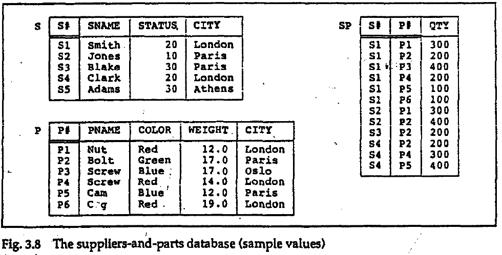

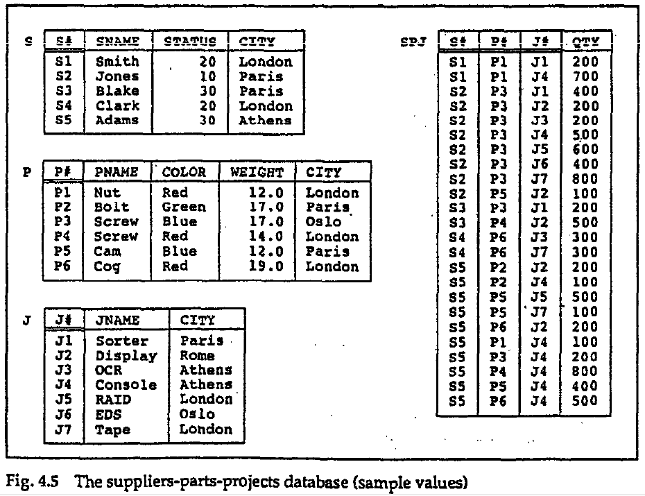

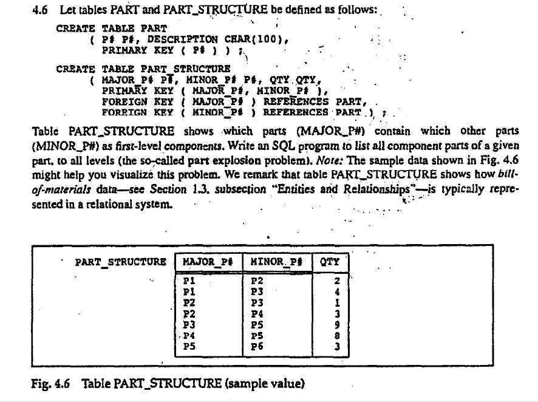

Create database from file:

```
createdb -h localhost -U user1 date_db
psql -h localhost -U user1 date_db -f example_db.sql -1
```

or paste these commands:

[output not shown]